# Point Process in INLA

I’m going to try and run a point process on the VPS data in INLA, heavily following the method outlined in (Moraga 2020). The same author also has a [free geospatial statistics with INLA textbook](https://www.paulamoraga.com/book-geospatial/) (Moraga 2019). I’d like an excuse to learn INLA, as it is supposed to be a Bayesian method that runs much more quickly than Monte Carlo-based methods, like JAGS or Stan. I’ve tried to use the `brms` package before, and tend to like it because it uses the same syntax as `mgcv` and `lme4`, for instance, but it takes a while to run all of the simulations on my computer.

The following is just pulling in all of the data.

```r
library(ggplot2); library(dplyr); library(sf); library(lwgeom)
positions <- data.table::fread(file.path('p:/obrien/biotelemetry/marshyhope/vps',
                                         'VPS-NanticokeRiver-Brookview-01-Results-20210106',
                                         'positions',
                                         'all-calc-positions.csv'),

                               # this just applies base::tolower to the column names
                               col.names = tolower)


## Fish positions
fish <- positions %>%
  filter(grepl('^\\d', transmitter))
fish <- fish %>%
  filter(hpe <= quantile(fish$hpe, 0.9, na.rm = T)) %>%
  st_as_sf(coords = c('lon', 'lat'),
           crs = 4326,
           remove = F) %>%
  st_transform(4269)

## Import Marshyhope shape (previously cropped to the above fish detections)
mh_shape <- st_read('data/derived/mhclip_base2020vpsfish.gpkg') %>%
  st_zm()
## Import habitat polygons that intersect with the mh_shape polygon
habitat <- st_read('data/raw/2015 Atlantic Sturgeon Habitat Geodatabase Nanticoke and Tributaries 01132016.gdb',
                   layer = 'RiverBed_Habitat_Polygons_CMECS_SC_01132016',
                   wkt_filter = st_as_text(st_geometry(mh_shape))) %>%

  # order bottom type from gravel to to sand to mud
  mutate(Group = ifelse(SubGroup == '<Null>', Group_, SubGroup),
         Group = factor(Group,
                        ordered = T,
                        levels = c('Sandy_Gravel',
                                   'Sand',
                                   'Muddy_Sand',
                                   'Sandy_Clay',
                                   'Sandy_Mud',
                                   'Mud',
                                   'Unclassified')))
```

## Spatial gymnastics

Here is where we stand with all the data we just imported:

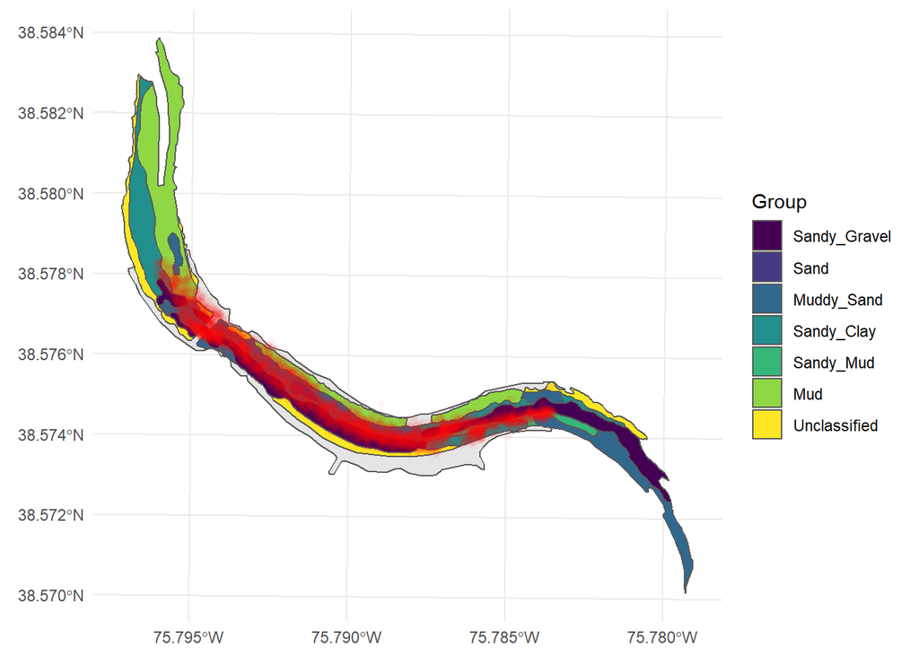

```r
ggplot() +
  geom_sf(data = mh_shape) +
  geom_sf(data = habitat, aes(fill = Group)) +
  geom_sf(data = fish, alpha = 0.03, color = 'red') +
  theme_minimal()
```

The code above imported any polygon that overlapped with the cropped Marshyhope Creek section. Now we want the full intersection – basically, we want to have it cropped down another level.

```r
habitat <- habitat %>%
  st_intersection(mh_shape)
```

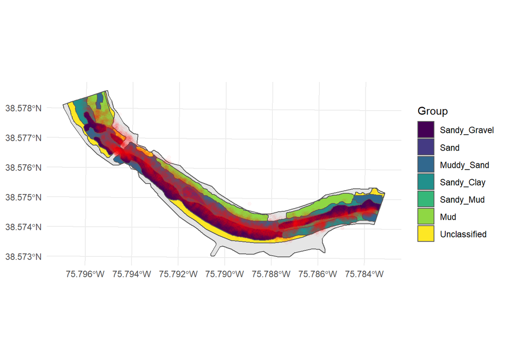

```r
ggplot() +
  geom_sf(data = mh_shape) +
  geom_sf(data = habitat, aes(fill = Group)) +
  geom_sf(data = fish, alpha = 0.03, color = 'red') +
  theme_minimal()
```

We can now see that there are areas that were not classified by the NOAA survey (even as “Unclassified”). They are the surrounding bits that are in gray. We now want to pull those bits out and classify them as “Unclassified”

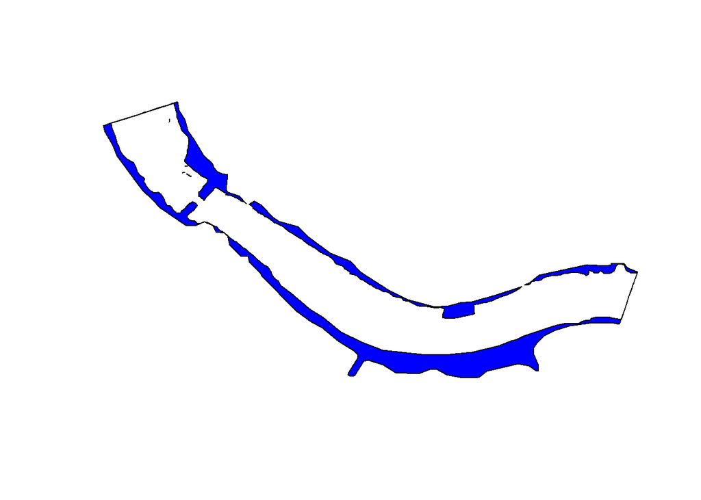

```r
# Select the important bits
habitat <- habitat %>%
  select(Group)

# Union the habitat polygons (lump them into one big polygon) and then subtract
#   that from the Marshyhope polygon
uncl <- st_sym_difference(st_union(habitat), mh_shape)

plot(uncl, col = 'blue')
```

```r
# Add the new unclassified back in
habitat <- uncl %>%
  st_as_sf()  %>%
  rename(Shape = x) %>%
  mutate(Group = 'Unclassified') %>%
  rbind(habitat)

habitat
```

|  | Group | Shape |
| --- | --- | --- |
| 1 | Unclassified |  |
| 2 | Sandy_Gravel |  |
| 3 | Sand |  |
| 4 | Unclassified |  |
| 5 | Mud |  |
| 6 | Sandy_Clay |  |
| 7 | Sandy_Clay |  |
| 8 | Muddy_Sand |  |
| 9 | Mud |  |
| 10 | Unclassified |  |

[output cut: 17 more lines]

```r
# Since we don't actually need each individual polygon indexed, we'll group
#   them all together
habitat <- habitat %>%
  group_by(Group) %>%
  summarize(geometry = st_union(Shape))

habitat
```

| Group | geometry |
| --- | --- |
| Mud |  |
| Muddy_Sand |  |
| Sand |  |
| Sandy_Clay |  |
| Sandy_Gravel |  |
| Sandy_Mud |  |
| Unclassified |  |

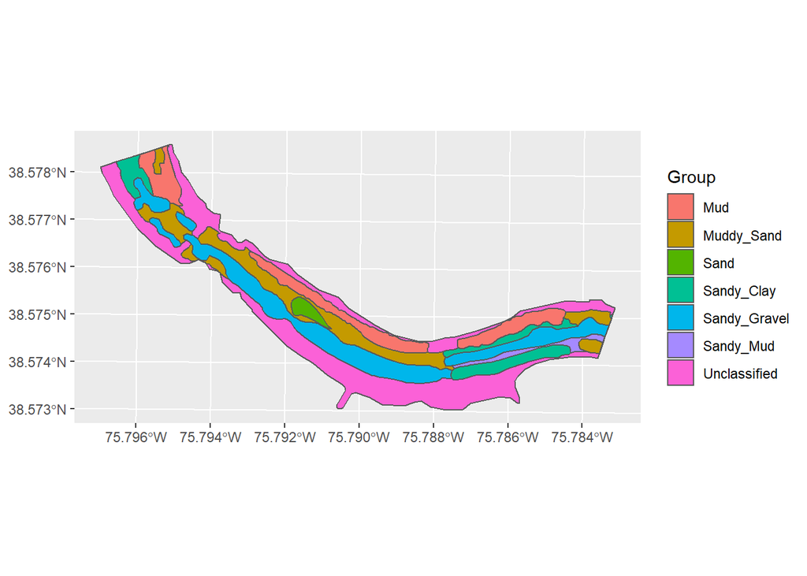

```r
ggplot(data = habitat) +
  geom_sf(aes(fill = Group))
```

## Adapting the data to fit

(Moraga 2020) creates a `raster::raster` data set to discretize the point data, which they then convert back to a vector. I think that I can just discretize the data in `sf`, cutting out the `raster` middle-man. Note that INLA will eventually want grid indexes to run top to bottom, then left to right.

### Make the grid

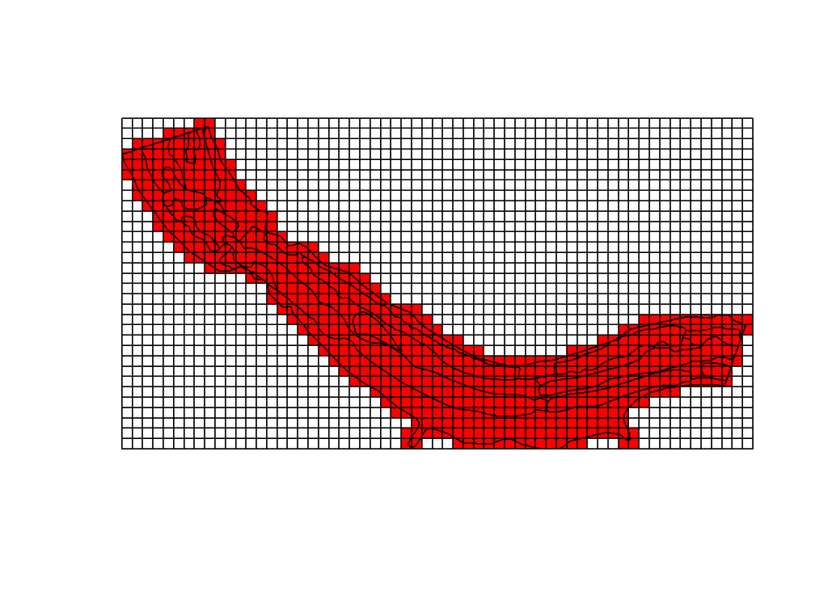

```r
grid_full <- habitat %>%
  # Our coordinate reference system has units of meters
  #   Make a 20m x 20m grid
  st_make_grid(c(20, 20)) %>%

  # Create IDs in the INLA order (top to bottom then left to right)
  st_as_sf() %>%
  mutate(centroid = st_centroid(x)) %>%
  cbind(st_coordinates(.$centroid)) %>%
  arrange(X, desc(Y)) %>%
  transmute(id = rownames(.))

# Select those grid cells that are covered by the polgyon or overlap with the
#   outline of Marshyhope Creek
grid <- grid_full[st_covered_by(grid_full, mh_shape, sparse = F) |
                    st_overlaps(grid_full, mh_shape, sparse = F),]

plot(st_geometry(grid_full))
plot(st_geometry(grid), add = T, col = 'red')
plot(st_geometry(habitat), add = T)
```

### Descritize habitat covariate (winner takes all)

Each grid cell will be assigned the bottom type that covers the most area in that grid cell.

```r
bot_type <- grid %>%

  # Crop the habitat polygons by each grid cell
  st_intersection(habitat) %>%

  # Calculate the area of each bottom type in the grid cell
  mutate(area = st_area(x)) %>%

  # Select the greatest area in each grid cell
  group_by(id) %>%
  filter(area == max(area)) %>%
  data.frame()
# Join the above back in with the grid
grid <- grid %>%
  left_join(bot_type[, names(bot_type) %in% c('id', 'Group')])
```

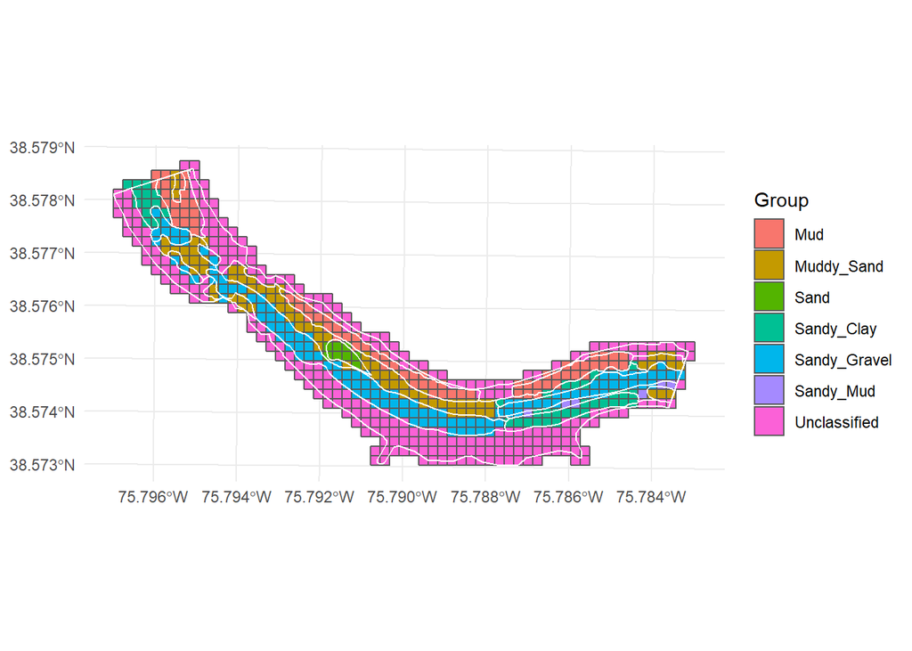

```r
ggplot(data = grid) +
  geom_sf(aes(fill = Group)) +
  geom_sf(data = habitat, fill = NA, color = 'white') +
  theme_minimal()
```

### Match fish detections with “winner take all” habitat grid

Now we find into which “winner-take-all” habitat each position fell and add that up for each grid cell and transmitter.

```r
fish_grid_id <- fish %>%
  st_transform(st_crs(grid)) %>%
  st_intersection(grid) %>%
  group_by(id, transmitter) %>%
  summarize(n_pos = n())
n_pos_grid <- grid %>%
  full_join(select(data.frame(fish_grid_id), id, transmitter, n_pos)) %>%
  mutate(n_pos = ifelse(is.na(n_pos), 0, n_pos))
```

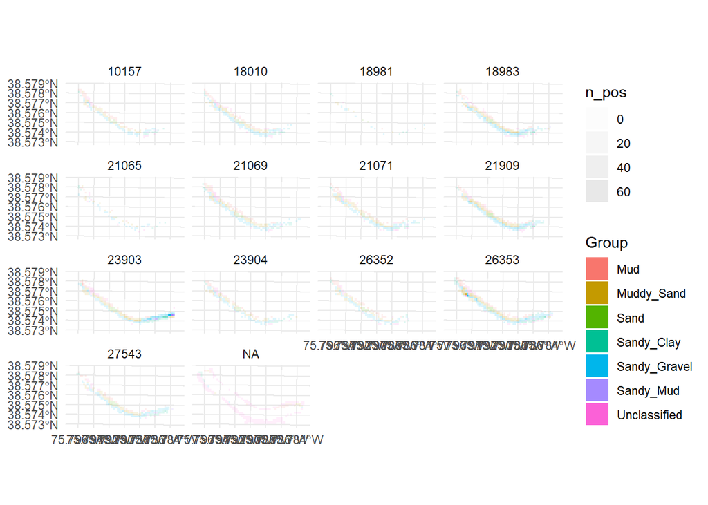

```r
ggplot(data = n_pos_grid) +
  geom_sf(aes(fill = Group, alpha = n_pos), color = NA) +
  facet_wrap(~ transmitter) +
  theme_minimal()
```

## Get data ready for INLA

```r
mod_data <- n_pos_grid %>%
  mutate(
    # Numeric ID for spatial random effects
    id = as.numeric(id),
    # Factor transmitter for iid random effects
    transmitter = as.factor(transmitter),

    # Area for offset
    area = as.numeric(st_area(x)),
    # Factorize group since that helps sometimes
    Group = as.factor(Group)
    )
```

## Run the model

```r
library(INLA)
res <- inla(n_pos ~ 1 + Group +

              # Random transmitter effect
              f(transmitter, model = 'iid') +

              # Random walk random effect -- "rw2d" for use on a grid
              f(id, model = 'rw2d',
                # Needs the number of rows and columns
                #   Using the bounding box divided by grid size
                ncol = (st_bbox(grid)$xmax - st_bbox(grid)$xmin) / 20,
                nrow = (st_bbox(grid)$ymax - st_bbox(grid)$ymin) / 20),
            family = "poisson", data = mod_data,
            E = area,
            control.predictor = list(compute = TRUE),
            control.compute = list(waic = TRUE))
```

## Results

```r
summary(res)
```

```
##
## Call:
##    c("inla(formula = n_pos ~ 1 + Group + f(transmitter, model = \"iid\") +
##    ", " f(id, model = \"rw2d\", ncol = (st_bbox(grid)$xmax -
##    st_bbox(grid)$xmin)/20, ", " nrow = (st_bbox(grid)$ymax -
##    st_bbox(grid)$ymin)/20), ", " family = \"poisson\", data = mod_data, E
##    = area, control.compute = list(waic = TRUE), ", " control.predictor =
##    list(compute = TRUE))")
## Time used:
##     Pre = 0.466, Running = 37.5, Post = 0.885, Total = 38.9
## Fixed effects:
##                      mean    sd 0.025quant 0.5quant 0.975quant    mode kld
## (Intercept)       -14.187 1.523    -17.228  -14.171    -11.240 -14.140   0
## GroupMuddy_Sand     0.042 0.105     -0.166    0.042      0.247   0.043   0
## GroupSand          -0.030 0.202     -0.428   -0.030      0.364  -0.029   0
## GroupSandy_Clay     0.031 0.134     -0.233    0.032      0.294   0.032   0
## GroupSandy_Gravel   0.112 0.115     -0.115    0.113      0.337   0.113   0
## GroupSandy_Mud      0.341 0.176     -0.007    0.341      0.686   0.342   0
## GroupUnclassified   0.043 0.134     -0.221    0.043      0.304   0.043   0
##
## Random effects:
##   Name     Model
##     transmitter IID model
##    id Random walk 2D
##
## Model hyperparameters:
##                            mean    sd 0.025quant 0.5quant 0.975quant  mode
## Precision for transmitter 0.114 0.065      0.034    0.099      0.279 0.075
## Precision for id          1.061 0.128      0.830    1.054      1.334 1.040
##
## Expected number of effective parameters(stdev): 203.04(6.55)
## Number of equivalent replicates : 12.35
##
## Watanabe-Akaike information criterion (WAIC) ...: 10344.43
## Effective number of parameters .................: 457.08
##
## Marginal log-Likelihood:  -7405.81
## Posterior marginals for the linear predictor and
##  the fitted values are computed
```

### Fixed effects

First, we’ll look at the posterior of the bottom type fixed effect.

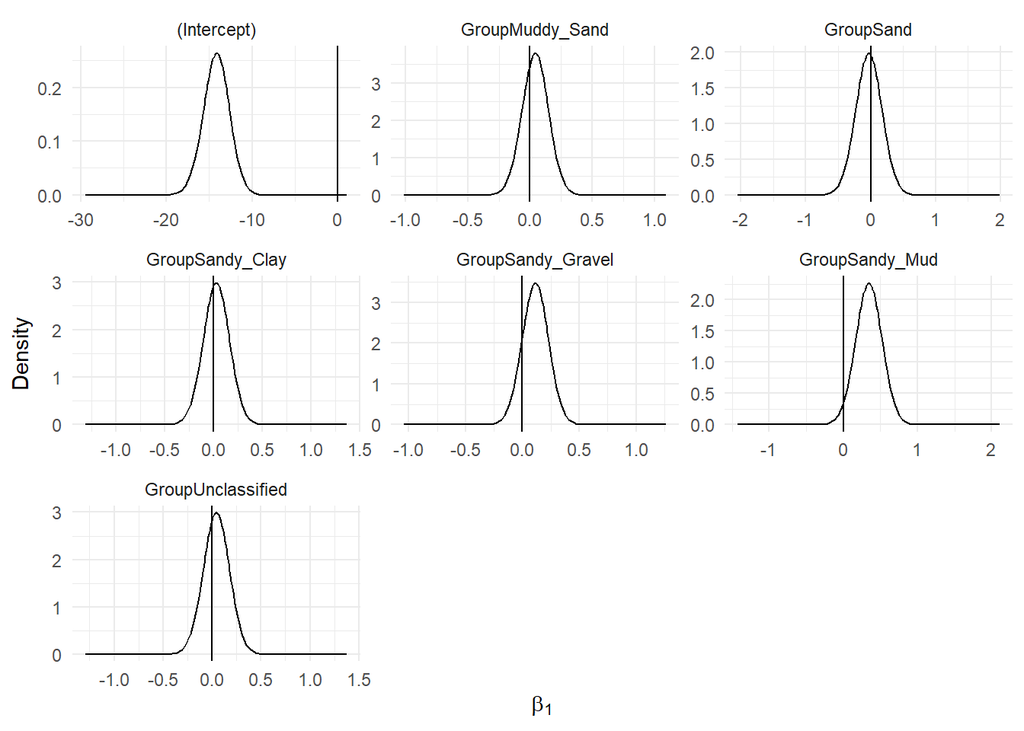

```r
list_marginals_fixed <- res$marginals.fixed

marginals <- data.frame(do.call(rbind, list_marginals_fixed))
marginals$group <- rep(names(list_marginals_fixed),
                       times = sapply(list_marginals_fixed, nrow))


ggplot(data = marginals,
       aes(x = x, y = y)) +
  geom_line() +
  geom_vline(xintercept = 0) +
  labs(x = expression(beta[1]), y = "Density") +
  facet_wrap(~ group, scales = 'free') +
  theme_minimal()
```

The “Intercept” in the plot of the marginals is mud: the coefficient for mud is significantly less than zero. All of the other bottom types are no different than zero (i.e.: they aren’t significant).

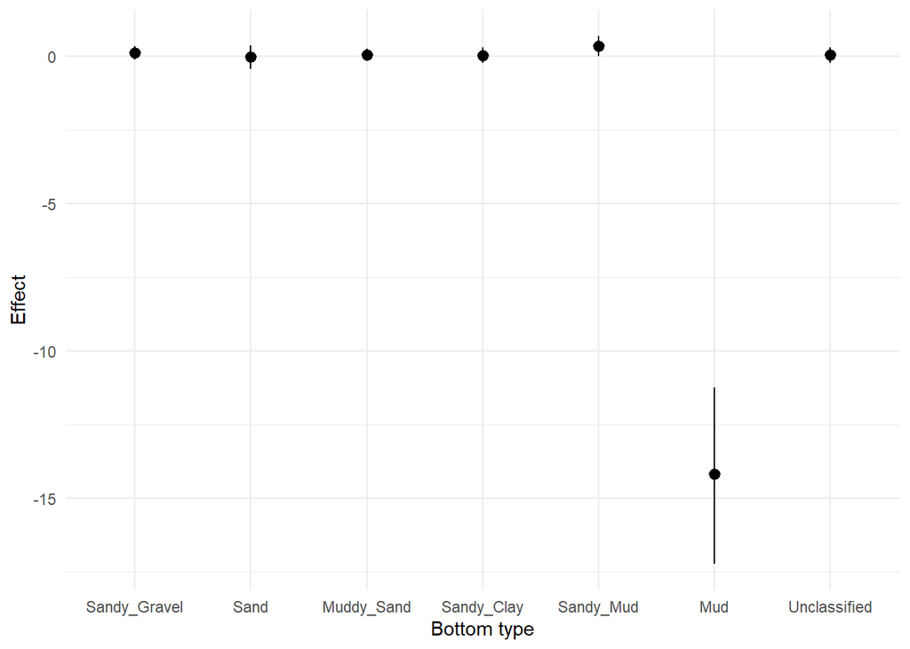

```r
summary_fixed <- res$summary.fixed %>%
  mutate(group = gsub('Group', '', row.names(.)),
         group = ifelse(group == '(Intercept)', 'Mud', group),
         group = factor(group, levels = c('Sandy_Gravel', 'Sand', 'Muddy_Sand',
                                          'Sandy_Clay', 'Sandy_Mud', 'Mud',
                                          'Unclassified'),
                        ordered = T))

ggplot(data = summary_fixed) +
  geom_pointrange(aes(x = group, y = `0.5quant`,
                      ymin = `0.025quant`, ymax = `0.975quant`)) +
  labs(x = 'Bottom type', y = 'Effect') +
  theme_minimal()
```

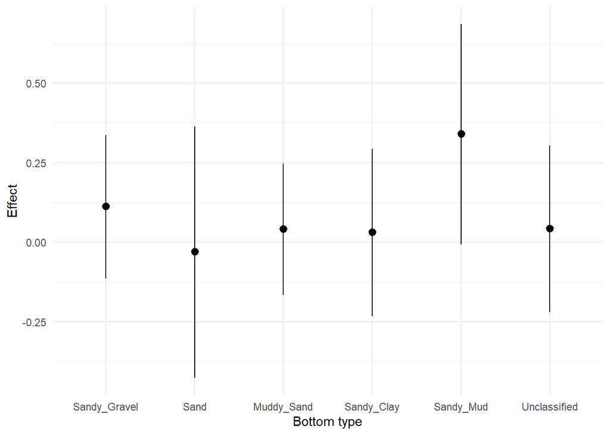

```r
ggplot(data = filter(summary_fixed, group != 'Mud')) +
  geom_pointrange(aes(x = group, y = `0.5quant`,
                      ymin = `0.025quant`, ymax = `0.975quant`)) +
  labs(x = 'Bottom type', y = 'Effect') +
  theme_minimal()
```

If we look at the median and confidence interval of the coefficients on the same scale we can see that the effect of mud is very poorly resolved. In fact, we need to remove it to see what’s going on with the other bottom types. As we saw before, none of the other bottom types are significantly different than zero. Sandy mud is almost there, but still no luck.

What does this look like on the response scale (number of positions per 20 m x 20 m grid)?

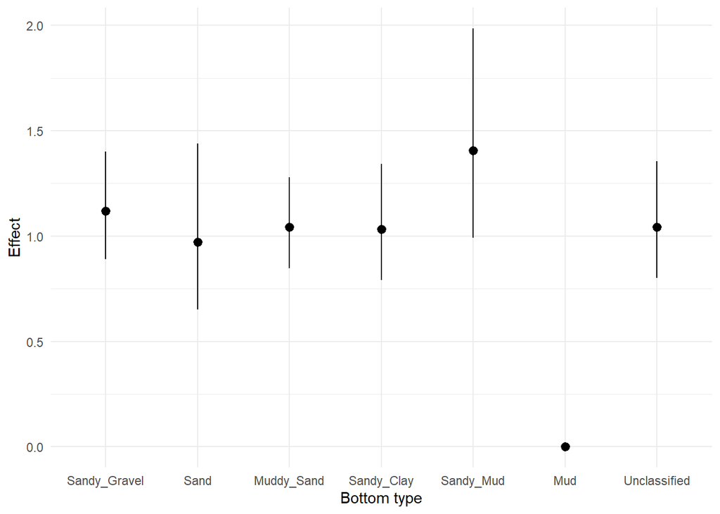

```r
summary_fixed <- summary_fixed %>%
  mutate(resp_0.025quant = exp(`0.025quant`),
         resp_0.5quant = exp(`0.5quant`),
         resp_0.975quant = exp(`0.975quant`))

ggplot(data = summary_fixed) +
  geom_pointrange(aes(x = group, y = resp_0.5quant,
                      ymin = resp_0.025quant, ymax = resp_0.975quant)) +
  labs(x = 'Bottom type', y = 'Effect') +
  theme_minimal()
```

Here, we can see again that mud is predicted to have basically no positions and all other bottom types are roughly equivalent around one position. All in all, bottom type can account for 0-2 positions in each grid cell.

### Random effects

First is the random effect of transmitter (individual fish). There do seem to be some differences here, though no individual fish is significantly different from the others. Note that since this is included as a random effect, everything is pulled toward the mean – this is likely to underestimate large differences. Might be interesting to see if there are any female fish in here.

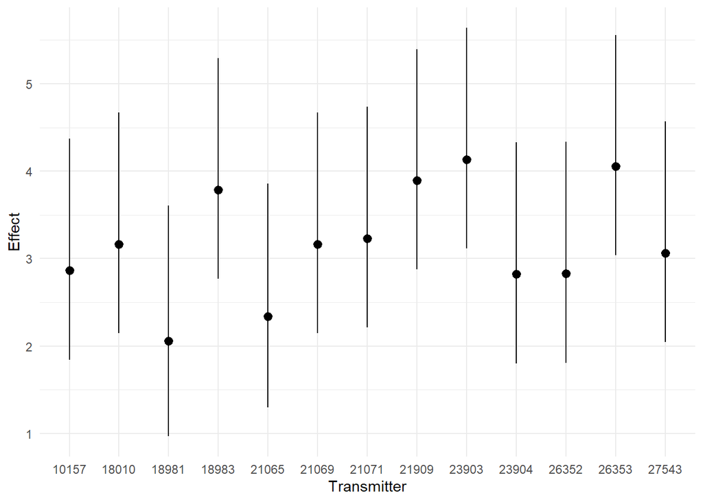

```r
summary_iid <- res$summary.random$transmitter

ggplot(data = summary_iid) +
  geom_pointrange(aes(x = ID, y = `0.5quant`,
                      ymin = `0.025quant`, ymax = `0.975quant`)) +
  labs(x = 'Transmitter', y = 'Effect') +
  theme_minimal()
```

Next is the interesting part: spatial autocorrelation! It looks like there are some hot spots not explained by sediment type or transmitter just north of the Brookview Bridge and near the southern end of the array. Note the scale of the effect – up to 7 more positions per fish in each grid cell! That far outweighs the 0-2 due to bottom type and is on the same order as the 1-6 due to differences between fish.

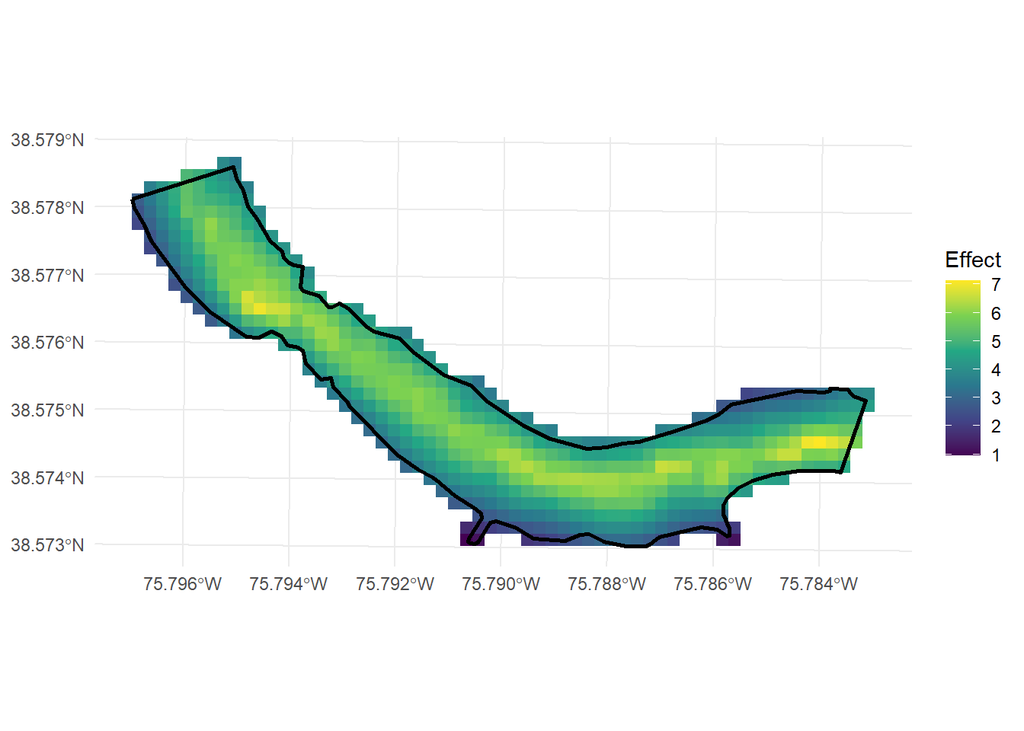

```r
mod_data <- mod_data %>%
  mutate(re_spat = res$summary.random$id[mod_data$id, "0.5quant"])

ggplot() +
  geom_sf(data = distinct(mod_data, id, .keep_all = T),
          aes(fill = re_spat), color = NA) +
  geom_sf(data = mh_shape, fill = NA, size = 1, color = 'black') +
  labs(fill = 'Effect') +
  scale_fill_viridis_c() +
  theme_minimal()
```

1. We’ve accidentally used Atlantic sturgeon to create an index of depth in Marshyhope Creek!
2. It displays in a nice, visual manner that a depth covariate would be very informative.
3. We now know that bottom type really isn’t very predictive of the number of detections in a grid cell.

### Predictions

Lastly, we’ll run some predictions.

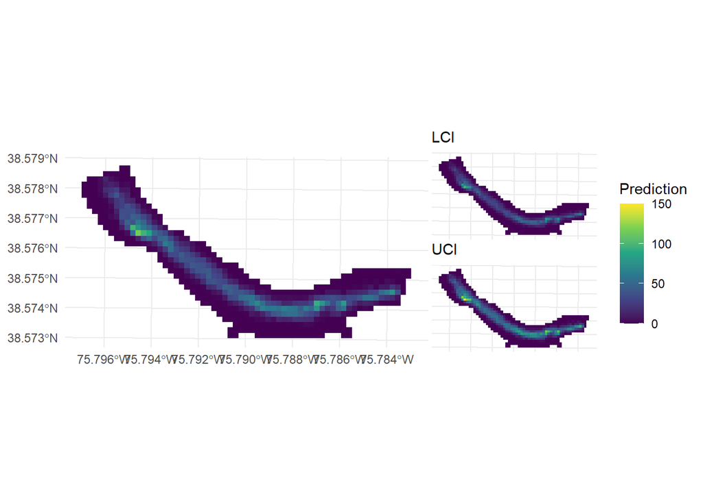

```r
cellarea <- 20*20
mod_data$pred <- res$summary.fitted.values[, "0.5quant"] * cellarea
mod_data$lci <- res$summary.fitted.values[, "0.025quant"] * cellarea
mod_data$uci <- res$summary.fitted.values[, "0.975quant"] * cellarea

preds <- mod_data %>%
  group_by(id) %>%
  summarise(s_pred = sum(pred),
            s_lci = sum(lci),
            s_uci = sum(uci))


library(patchwork)
pred_plot <- ggplot(data = preds) +
  geom_sf(aes(fill = s_pred), color = NA, show.legend = F) +
  scale_fill_viridis_c(limits = c(0, 150)) +
  theme_minimal()+
  theme(plot.margin = margin(0, 0, 0, 0))

lci_plot <- ggplot(data = preds) +
  geom_sf(aes(fill = s_lci), color = NA) +
  labs(fill = 'Prediction', subtitle = 'LCI') +
  scale_fill_viridis_c(limits = c(0, 150)) +
  theme_minimal() +
  theme(axis.text = element_blank(),
        plot.margin = margin(0, 0, 0, 0))

uci_plot <- ggplot(data = preds) +
  geom_sf(aes(fill = s_uci), color = NA) +
  labs(fill = 'Prediction', subtitle = 'UCI') +
  scale_fill_viridis_c(limits = c(0, 150)) +
  theme_minimal() +
  theme(axis.text = element_blank(),
        plot.margin = margin(0, 0, 0, 0))

pred_plot + (lci_plot / uci_plot) + plot_layout(widths = c(2.2,1), guides = 'collect')
```

Mud had significantly fewer positions than all other bottom types. Other bottom types did not vary significantly from each other, nor were they significant in the model.

The spatial random effect, which represents unknown spatially-autocorrelated variables, could create a difference of more than 7 positions per fish in a given 20m x 20m cell. As the highest intensity mirrors the channel of the Marshyhope, this is likely to be due to association with depth. Differences associated with individual fish also cause differences of 1-6 positions per cell.

Compared to the random effects of spatial autocorrelation and individual fish, which were on the order of 0-7 detections, the fixed effect of bottom type, which ranged from 0-2 positions, was not as great. As is clear from the spatial random effect, bottom type is not a dominant – nor even informative – predictor of Atlantic sturgeon positions in the VPS. A crucial next step for informative modeling of Atlantic sturgeon detections would be to collect bathymetry data in this area of the Marshyhope in at least a 20 x 20m scale.

## References

Moraga, Paula. 2019. *Geospatial Health Data: Modeling and Visualization with r-INLA and Shiny*. CRC Biostatistics Series. Chapman & Hall. https://www.paulamoraga.com/book-geospatial/.

———. 2020. “Species Distribution Modeling Using Spatial Point Processes: A Case Study of Sloth Occurrence in Costa Rica.” *The R Journal* 12 (2): 293. https://doi.org/10.32614/RJ-2021-017.